# Cross Validation

Applied Machine Learning in Economics

Today we are going to compare cross-validation (CV) techniques on some relatively simpler models. We are going to use CV on a regression (continuous) and classification problem.

# 1 Setup

For this lecture, we are going to use both the continuous and discrete data. We are also going to explore the `caret` package.

## 1.1 Loading the Stuff

In case you haven’t noticed up to this point that the package `tidyverse` is a collection of multiple packages, looking at the `Attaching Packages` section of the printed message from loading `tidyverse`. It tells us what version of these packages we are using.

We also need to set the seed, because sample-splitting and cross-validation requires random draws.

```r
library(tidyverse)
library(caret)
# r for regression
ahsr = read.csv('C:/Users/johnj/Documents/Data/Applied ML ECON490/Lecture Data/lecture data continuous.csv')

# c for classification
ahsc = read.csv('C:/Users/johnj/Documents/Data/Applied ML ECON490/Lecture Data/lecture data discrete.csv')

set.seed(490)
```

## 1.2 Sample-Splitting

Time to split the data! I am feeling like the number 67 today. It’s basically $\frac{2}{3}$ AND is prime! Now that we are becoming more familiar with programming in `R`, let’s put on our big-kid pants and use `sample_frac`.

```r
trainr = sample_frac(ahsr, 0.67)
testr  = anti_join(ahsr, trainr, by = 'id')

trainc = sample_frac(ahsc, 0.67)
testc  = anti_join(ahsc, trainc, by = 'id')
```

# 2 Cross-Validation

We talked about LOOCV and $k$-fold CV. We will implement these two techniques and an additional technique: repeated $k$-fold cross-validation.

## 2.1 LOOCV

Don’t ever use LOOCV.

Okay, now that I have got that out of the way, let me show you how to do it. The reason we don’t want to use it is because of the high likelihood of over fitting. It is still nonetheless important to know how to use a technique and why we don’t like it.

```r
# initializing the cross-validation
trControl = trainControl(method = 'LOOCV')

# Defining the formula outside of the function, because I can't handle the clutter
f = as.factor(npeople) ~ log(hinc)

# Be carful with LOOCV

system.time(
{ # Need to wrap in curly brackets, otherwise system.time thinks it is function input
fit = train(f,
            method = 'knn',
            trControl = trControl,
            tuneGrid = expand.grid(k = 2^(4:6)), # type ?knn, note k is a parameter of knn()
            metric = "Accuracy",
            data = trainc[1:3000, ])
}
)
```

```
##    user  system elapsed
##   34.48    0.05   34.61
```

```r
fit
```

```
## k-Nearest Neighbors
##
## 3000 samples
##    1 predictor
##    3 classes: '1', '2', '3'
##
## No pre-processing
## Resampling: Leave-One-Out Cross-Validation
## Summary of sample sizes: 2999, 2999, 2999, 2999, 2999, 2999, ...
## Resampling results across tuning parameters:
##
##   k   Accuracy  Kappa
##   16  0.518     0.1916382
##   32  0.531     0.2049379
##   64  0.542     0.2196042
##
## Accuracy was used to select the optimal model using the largest value.
## The final value used for the model was k = 64.
```

```r
fit$bestTune
```

```
##    k
## 3 64
```

```r
dim(trainc)
```

```
## [1] 10375    20
```

```r
length(3:6)
```

```
## [1] 4
```

Checking for just *three* values of k on our small subset of `trainc` of just 3,000 observations on a single feature (ML speak for x-variables) took half a minute! could you imagine how long it would take if we used the whole training set and more variables? I know I certainly can’t (although this is actually a knowable/calculable number).

I don’t even want to mess around with the continuous case, so let’s just move on to something we will actually use…

**Question** Why did I use `as.factor` around `npeople`?

## 2.2 $k$-Fold CV

Unlike LOOCV, the $k$-fold CV is much faster and suffers significantly less from overfitting the training sample.

### 2.2.1 Discrete

Let’s try that same model again, but with 8 (because $0+1*2^3$, duh!) $k$-folds.

```r
trControl = trainControl(method = 'cv',
                         number = 8)

# You are welcome to define f inside of train() if you wish
f = as.factor(npeople) ~ log(hinc)

# Be carful with LOOCV

system.time(
{ # Need to wrap in curly brackets, otherwise system.time thinks it is function input
fit = train(f,
            method = 'knn',
            trControl = trControl,
            tuneGrid = expand.grid(k = 2^(4:6)), # type ?knn, note k is a parameter of knn()
            metric = "Accuracy",
            data = trainc[1:3000, ])
}
)
```

```
##    user  system elapsed
##    0.68    0.00    0.70
```

```r
fit
```

```
## k-Nearest Neighbors
##
## 3000 samples
##    1 predictor
##    3 classes: '1', '2', '3'
##
## No pre-processing
## Resampling: Cross-Validated (8 fold)
## Summary of sample sizes: 2625, 2625, 2625, 2626, 2626, 2624, ...
## Resampling results across tuning parameters:
##
##   k   Accuracy   Kappa
##   16  0.5213467  0.1982574
##   32  0.5313326  0.2072194
##   64  0.5446855  0.2245348
##
## Accuracy was used to select the optimal model using the largest value.
## The final value used for the model was k = 64.
```

```r
fit$bestTune
```

```
##    k
## 3 64
```

Less than a second! Much better!

Now we can add some complexity to the model and use the whole `trainc` data.

```r
trControl = trainControl(method = 'cv',
                         number = 8)

f = as.factor(npeople) ~ log(hinc) + beds*baths + condo + garage + crime


system.time(
{ # Need to wrap in curly brackets, otherwise system.time thinks it is function input
fit = train(f,
            method = 'knn',
            trControl = trControl,
            tuneGrid = expand.grid(k = 2^(4:6)), # type ?knn, note k is a parameter of knn()
            metric = "Accuracy",
            data = trainc)
}
)
```

```
##    user  system elapsed
##    2.73    0.00    2.73
```

```r
fit
```

```
## k-Nearest Neighbors
##
## 10375 samples
##     6 predictor
##     3 classes: '1', '2', '3'
##
## No pre-processing
## Resampling: Cross-Validated (8 fold)
## Summary of sample sizes: 9078, 9078, 9078, 9078, 9078, 9079, ...
## Resampling results across tuning parameters:
##
##   k   Accuracy   Kappa
##   16  0.5507453  0.2583337
##   32  0.5637575  0.2681638
##   64  0.5582638  0.2498730
##
## Accuracy was used to select the optimal model using the largest value.
## The final value used for the model was k = 32.
```

```r
fit$bestTune
```

```
##    k
## 2 32
```

### 2.2.2 Continuous

We can also apply `caret` to a continuous model! I think we should explore some polynomials of different orders. However, notice from the function call:

`lm(log(value) ~ poly(math, degree = i), data = trainr)`

that the `degree = i` is an argument of the `poly()` function, not `lm()`. This means we can’t use the `tuneGrid` argument of `train()`. Instead, we get to use our lovely `for` loop!

For expositional purposes, let’s try fitting this model:

`lm(log(value) ~ poly(log(hinc), yos, i) + poly(math, j))`

As a note, we will have to use the function `bquote()` and `as.formula()` to create our formula. Otherwise, the `i` and the `j` won’t be input into the model because `train()` won’t see that it needs to grab these values from the Global Environment. `as.formula()` seems self-explanatory, but check out `?bquote` for more information.

*Note: expand.grid() produces a* `data.frame` *by default*.

```r
results = data.frame(expand.grid(0:2, 1:3),
                     r2 = NaN,
                     rmse = NaN)
names(results)[1:2] = c('i', 'j')
results
```

```
##   i j  r2 rmse
## 1 0 1 NaN  NaN
## 2 1 1 NaN  NaN
## 3 2 1 NaN  NaN
## 4 0 2 NaN  NaN
## 5 1 2 NaN  NaN
## 6 2 2 NaN  NaN
## 7 0 3 NaN  NaN
## 8 1 3 NaN  NaN
## 9 2 3 NaN  NaN
```

```r
trControl = trainControl(method = 'cv',
                         number = 8)

# initializing i and j
i = j = 1

f = bquote(log(value) ~ poly(log(hinc), yos, degree = .(i)) + poly(math, .(j))) %>% as.formula

index = 0
for(i in 0:2){
  for(j in 1:3){
    index = index + 1
    fit = train(f,
                method = 'lm',
                data = trainr,
                trControl = trControl)
    results$r2[index] = fit$results$Rsquared
    results$rmse[index] = fit$results$RMSE # root mean squared error
  }
}

results
```

```
##   i j        r2     rmse
## 1 0 1 0.1266282 1.106719
## 2 1 1 0.1326698 1.101510
## 3 2 1 0.1272775 1.106181
## 4 0 2 0.1271307 1.108292
## 5 1 2 0.1269829 1.103142
## 6 2 2 0.1268834 1.106776
## 7 0 3 0.1298569 1.103897
## 8 1 3 0.1261805 1.104933
## 9 2 3 0.1289484 1.103138
```

Just as a reminder, we are grabbing the $R^2$ and the RMSE from the validation set. While we can go through that table, let’s plot the $R^2$ values instead. Since we are looking over *two* variables, we can produce a heatmap!

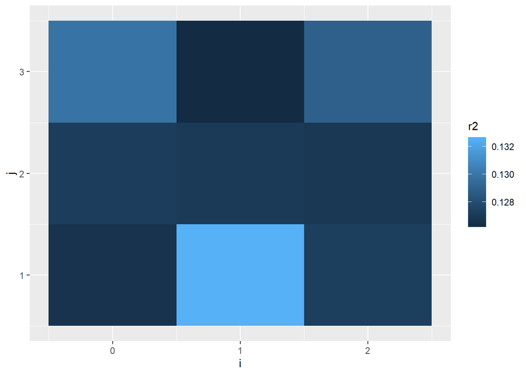

```r
ggplot(results, aes(x = i, y = j, fill = r2)) +
  geom_tile()
```

**Warning**: polynomials above degree two or three tend to lead to overfitting.

## 2.3 Repeated $k$-Fold CV

Repeated $k$-fold CV is an extension to the base $k$-fold CV. It is named pretty well; once it has do the first round of $k$ sub-sample splits, it repeats. The number of times that it repeats is up to the researcher (you).

The intuition behind repeated $k$-fold is rather straight forward. With the base $k$-fold, we are using only a “small sample” of fitted models, which means our accuracy estimates are noisy. So, we instead estimate more models using different splits. As we will discuss more in neural networks, using the training sample again is called an *epoch.*

### 2.3.1 Discrete

The setup and execution should start to seem familiar:

```r
trControl = trainControl(method = 'repeatedcv',
                         number = 8,
                         repeats = 10)

f = as.factor(npeople) ~ log(hinc) + beds*baths + condo + garage + crime


system.time(
{ # Need to wrap in curly brackets, otherwise system.time thinks it is function input
fit = train(f,
            method = 'knn',
            trControl = trControl,
            tuneGrid = expand.grid(k = 2^(4:6)), # type ?knn, note k is a parameter of knn()
            metric = "Accuracy",
            data = trainc)
}
)
```

```
##    user  system elapsed
##   24.15    0.09   24.27
```

```r
fit
```

```
## k-Nearest Neighbors
##
## 10375 samples
##     6 predictor
##     3 classes: '1', '2', '3'
##
## No pre-processing
## Resampling: Cross-Validated (8 fold, repeated 10 times)
## Summary of sample sizes: 9078, 9079, 9078, 9078, 9077, 9079, ...
## Resampling results across tuning parameters:
##
##   k   Accuracy   Kappa
##   16  0.5541294  0.2634353
##   32  0.5614361  0.2649852
##   64  0.5598740  0.2526600
##
## Accuracy was used to select the optimal model using the largest value.
## The final value used for the model was k = 32.
```

```r
fit$bestTune
```

```
##    k
## 2 32
```

Just as a general note that you might be starting to pick up on by now, KNN takes a longer than other techniques we have use so far. **Question** why is this?

### 2.3.2 Metric Confidence Intervals

Now that we have gotten to the last (in my opinion best) of the CVs, I will share a secret with you. `train()` produces standard deviations of the metrics!

```r
fit$results$AccuracySD
```

```
## [1] 0.01092261 0.01043221 0.01190165
```

We can use these to construct confidence intervals! Following the empirical rule, we have:

| Standard Deviations | Confidence Interval P-Value |
| --- | --- |
| 1 | 68% |
| 2 | 95% |
| 3 | 99.7% |

Let’s create a 95% confidence interval of the model with the best accuracy, $k = 32$. We are doing this to see if we can statistically distinguish from the case of $k = 16$. If not, we should choose the more parsimonious model.

```r
mean32 = fit$results$Accuracy[2]
sd32 = fit$results$AccuracySD[2]

ci95 = c(mean32 - 2*sd32, mean32 + 2*sd32)

mean16 = fit$results$Accuracy[1]

# Is the mean of k=16 in the confidence interval of k=32?
mean16 >= ci95[1] & mean16 <= ci95[2]
```

```
## [1] TRUE
```

Looks like we should choose the $k=16$ model.

### 2.3.3 Continuous

We can use the same setup as the regular $k$-fold CV. However, since at this point in the course we don’t have any “real” hyperparameters to work with, I will spend more time with this beginning with the regularization lecture.